# MUSA 500, Assignment #2

Minwook Kang, Nissim Lebovits, Ann Zhang

2022-11-22

# 1 Introduction

## 1.1 Problem & Setting

As in [our previous homework assignment](https://rpubs.com/nlebovits/musa-550-assign-1-ed-2), this study aims to examine the relationship between median house values and several neighborhood characteristics. It will establish a model for predicting median house values, with a geographic focus on Philadelphia. Earlier models of house value prediction—especially the influential HUD report, *Characteristic Prices of Housing in Fifty-Nine Metropolitan Areas*—propose a hedonic model, which has been widely adopted and which we will use here.[^1]

$$R = f (S, N, C, t)$$
where

$R =$ rent or value,

$S =$ structural characteristics,

$N =$ neighborhood characteristics (including location),

$C =$ contract conditions (implicit and explicit), and

$t =$ time trend (accounting for inflation over time).

In a subsequent study that looks at Place-to-place Housing Price Indexes and their determinants, the researchers utilized the log-linear form of the hedonic model,[^2] expressed as:

$$\ln R = \beta_0 + S\beta_1 + N\beta_2 +
L\beta_3 + C\beta_4 + \epsilon$$
where

$\ln R =$ the natural log of rent,

$R, S, N, C =$ same as above,

$\beta_i =$ the hedonic regression coefficient, and

$\epsilon$ = the residuals.

Since the researchers mentioned “four appealing characteristics” of the log-linear form, including mitigating a common form of heteroskedasticity,[^3] our study will also use the logarithmic transformation of some variables.

Both studies identified and categorized structural, neighborhood, and contract characteristics as three separate groups. Nonetheless, the analysis primarily focused on the structural characteristics (e.g., the number of bedrooms) and oversimplified the variables in neighborhood characteristics (i.e., using a generic subjective rating of how “good” a neighborhood is instead of using more objective parameters). Given that previous studies largely focused on structural characteristics, we will adopt similar regression models to explore four neighborhood characteristics that were previously overlooked:

1. the percentage of individuals with Bachelor’s degrees or higher,
2. the percentage of vacant houses,
3. the number of households living in poverty, and
4. the percentage of single family housing units.

In [our previous homework assignment](https://rpubs.com/nlebovits/musa-550-assign-1-ed-2), we found that the map of standardized residuals showed signs of spatial autocorrelation, which undermined the viability of our OLS regression model. In this assignment, we attempt to account for the influence of spatial autocorrelation by by using various spatial regression techniques, including spatial lag, spatial error, and geographically weighted regression.

## 1.2 Prior Analysis

In Homework #1, we utilized OLS (ordinary least sqaures) regression to build a model looking at the relationship between a dependent variable (log-transformed median house values) and four predictors (percentage of vacant houses, percentage of single family houses, percentage of residents holding a Bachelor’s degree or higher, and log-transformed poverty rate).

## 1.3 Issues with OLS

Although the result of our OLS regression model was relatively acceptable for social science research, it inevitably suffered from OLS regression’s inability to address the spatial component of our dataset. Given the geographic nature of house price data, taking saptial elements into consideration may substantially improve our model.

## 1.4 Improving on OLS

This project aims to incorporate the spatial components of our data by considering spatial lag, spatial error, and geographically weighted regression (GWR). In the results and discussion sections, we will revisit the OLS approach from last project and make comparisons between different approaches, and suggest whether spatial lag, spatial error, and/or GWR perform better than OLS.

# 2 Methods

## 2.1 Spatial Autocorrelation

Spatial autocorrelation looks at how the value of a variable for an observation varies in comparison to values for other observations nearby. In other words, it is the relationship of values of a single variable at neighboring locations. Positive spatial autocorrelation suggests more similar values at proximate locations, while negative spatial autocorrelation suggests greater differences in the value of the variable for more proximate observations.

### 2.1.1 Tobler’s 1st Law

Spatial autocorrelation is based on Waldo Tobler’s First Law of Geography. Proposed in 1970, Tobler’s First Law states that, “everything is related to everything else, but near things are more related than distant things.” Because of this potential association between values of a variable and their locations, spatial statistics and autocorrelation should be taken into consideration in models.

### 2.1.2 Moran’s I

One of the most commonly used tests for spatial autocorrelation (also known as spatial dependencies) is Moran’s I. Larger positive values of Moran’s I indicate a stronger positive spatial autocorrelation (geospatial clustering of similar values), while larger negative values indicate a strong negative correlation (spatial dispersion of similar values). Value closer to 0 indicate little to no spatial autocorrelation, i.e., random distribution.

### 2.1.3 Weight Matrices

Weight matrices are a $n * n$ table (given $n$ observations in the dataset) that is useful for calculating spatial autocorrelation indices (which means, quantifying the extent of spatial autocorrelation). There are different types of weight matrices, with “rook” and “queen” being the two most frequently used contiguity-based spatial weights. Often, statisticians try several different weight matrices to ensure that their results are universal, unless they have theoretical reasoning that strongly suggest the application of a particular weight matrix.

In this project, we are using a queen weight matrix, which accounts for neighbors that are directly next to and diagonally linked to the area of interest. In comparison to a rook weight matrix, which does not account for diagonal areas (only four directions reflected, up, down, left, and right), queen weights do a better job reflecting neighboring values in all eight directions.

### 2.1.4 Significance Testing

To test the significance of our our spatial autocorrelation tests (Moran’s I), we are using a Monte Carlo approach. This process requires us to shuffle the value of the dependent variable 999 times, recalculate the Moran’s I value for each permutation, then rank and compare the original Moran’s I value with all 999 permutations. We calculate a pseudo p-value by taking the rank of the original Moran’s I compared to the permutations and dividing it by 1,000. The pseudo p-value helps us test the significance of our Moran’s I and test our hypotheses, which are:

$H_0$ = there is no spatial autocorrelation (i.e., the pattern is random)

$H_a$ = there is spatial autocorrelation, whether positive or negative

### 2.1.5 Local vs. Global Spatial Autocorrelation

Developed by Luc Anselin, Local Indices of Spatial Autocorrelation (LISA) are used for calculating local spatial autocorrleation. Unlike the global Moran’s I, which generates one value, LISAs generates a local Moran’s I value for each location. While the global Moran’s I helps us understand the entire dataset, the local Moran’s I values help us dig into specific locations and see how they compare to their neighbors. Our project calculates local Moran’s I values in order to carry out further analysis of spatial autocorrelation.

## 2.2 OLS Regression and Assumptions

### 2.2.1 Overview of OLS Regression

OLS (Ordinary least squares) is a method to explore relationships between a dependent variable and one or more explanatory variables. It considers the strength and direction of these relationships and the goodness of model fit. (For more information, please refer to [our previous homework assignment](https://rpubs.com/nlebovits/musa-550-assign-1-ed-2).) When running an OLS regression, it is crucial to ensure that the following five assumptions are not violated:

1. A linear relationship between the dependent variable and predictors
2. Normality of residuals
3. Homoscedasticity
4. Independence of observations (no spatial, temporal or other forms of dependence in the data)
5. No multicollinearity

In Homework #1, we showed that three of above five OLS assumptions were violated. First, the relationships between our dependent variable and the predictor variables were generally not linear. Additionally, the scatterplot of predicted values compared to standardized residuals showed heteroscedasticity. Finally, our map of the standardized residuals showed signs of spatial autocorrelation, indicating systematic patterns in our data, violating the fourth assumption. These three issues undermine key assumptions of linear regression.

### 2.2.2 Random Errors in Spatial Data

When residuals contain a systematic pattern, the assumption of randomness of residuals is not met. Specifically, if we have spatially autocorrelated OLS residuals, there is systematic under-prediction or over-prediction in certain parts of the study region; furthermore, the significance estimates for the $\beta$ coefficients in OLS may be incorrect (inflated). There are a couple ways to check for spatial autocorrelation of the OLS residuals, though the first thing to do might be to map the residuals. We want the map of the residuals to look random; this would imply that our model is not spatially autocorrelated. After looking at the residual maps, we would want to compute the global Moran’s I of the residuals. Ideally, we will see a Moran’s I close to 0, there is an obvious problem with spatial autocorrelation of residuals.

Below in section 3.2.2, we will regress residuals $\hat{ε}$ on the spatially lagged residuals $W\hat{ε}$. Ideally, we would see that there is no relationship between $\hat{ε}$ and $W\hat{ε}$ – that is, that the coefficient of $W\hat{ε}$, which we denote as $\beta_1$, is not significantly different from 0. $\beta_1$ can range between -1 and 1. We are able to regress residuals on the nearest neighbor residuals, thereby filtering the spatial information out of the OLS residuals and decomposing the residuals $ε$ into two parts: one with a spatial pattern $λWε$ and one which is simply random noise $u$.
$$y = β_0 + β_1X_1 +...+ β_nX_n +λWε+
u$$

### 2.2.3 Testing Other Regression Assumptions in R

Below, in section 3.2 and section 3.3, we will test the null hypothesis of homoscedasticity against the alternative hypothesis of heteroscedasticity using the following tests:

1. Koenker-Bassett Test : Robust Tests for Heteroscedasticity Based on Regression Quantiles
2. Breusch-Pagan Test : Simple test for heteroscedasticity and random coefficient variation
3. White Test : A Heteroskedasticity-Consistent Covariance Matrix Estimator and a Direct Test for Heteroskedasticity.

For these tests, $H_0$ is the assumption of homoscedasticity, while $H_a$ is the presence of heteroscedasticity. If the p-value < 0.05, we can reject $H_0$.

Another important assumption is the normality of residuals. When residuals are not normal, we may run into issues with both OLS regression and spatial regression. We can check the normality of residuals by:

1. Examining the histogram of residuals, and
2. Running the Jarque-Bera test.

Here, $H_0$ is the normality of residuals, while $H_a$ is the non-normal distribution of residuals, If the p-value < 0.05, we can reject $H_0$.

## 2.3 Spatial Lag and Spatial Error Regression

### 2.3.1 Spatial Lag Regression

The spatial lag model assumes that the value of the dependent variable at one location is associated with the values of that variable in nearby locations. “Nearby” is as defined by the weights matrix W (rook, queen, or within a certain distance of one another). In other words, the spatial lag model includes the spatial lag of the dependent variable as a predictor. In this assignment, our equation for the Spatial Lag Model is as follow:
$$LNMEDHVAL
=
ρWy\;+\;β_0\;+\;LNNBELPOVβ_1\;+\;PCTBACHMORβ_2\;+\;PCTSINGLESβ_3\;+\;PCTVACANTβ_4\;+\;ε$$
Here, $ρ$ is the coefficient of the $y-lag$ variable $Wy$, just as $β_1$ is the coefficient of the variable $LNNBELPOV$, and $ε$ is the residual term.

It may be help to consider spatial lag through the analogy of this Stats Wizard Penguin (SWP) and his Inept Companions (ICs): although the SWP may have a stats wizardry quotient (SWQ) of over 9,000, its spatial lag (i.e., the average value of the SWQs of its neighboring ICs) is 0 because all the neighboring penguins know exactly 0 about statistics. (Crucially, we should use a symmetrical matrix of statistically incompetent penguins, as this is a key requirement of spatial lag and spatial error regressions).

> The one person in the lab who really knows statistics [pic.twitter.com/dmLbkXG7mN](https://t.co/dmLbkXG7mN)

> — Björn Schumacher @schumacherbj@qoto.org (@schumacherbj) [October 23, 2022](https://twitter.com/schumacherbj/status/1584278266546130944?ref_src=twsrc%5Etfw)

### 2.3.2 Spatial Error Regression

The spatial error model assumes that the *residual* at one location is associated with *residuals* at nearby locations. “Nearby” is as defined by the weights matrix W (rook, queen, or within a certain distance of one another). This requires two steps: First, we run our OLS regression, where we regress Y on the predictors.
$$LNMEDHVAL =
β_0\;+\;LNNBELPOVβ_1\;+\;PCTBACHMORβ_2\;+\;PCTSINGLESβ_3\;+\;PCTVACANTβ_4\;+\;ε$$
Second, we regress the residuals on the nearest neighbor residuals, thereby filtering the spatial information out of the OLS residuals and decomposing the residuals $ε$ into two parts, one with a spatial pattern $λWε$ and one which is simply random noise $u$.

$$ε = λWε\;+\; u$$
The part with a spatial pattern can be thought of as some variable with a spatial component missing from the first OLS regression.
$$LNMEDHVAL =
β_0\;+\;LNNBELPOVβ_1\;+\;PCTBACHMORβ_2\;+\;PCTSINGLESβ_3\;+\;PCTVACANTβ_4\;+\;
λWε\;+\; u$$

### 2.3.3 Assumptions for Spatial Lag and Error Regression

With both spatial lag and spatial error regression models, we still retain all of the assumptions of OLS *except for the spatial independence of observations.* The relationship between the independent variable and each of the dependent variables must still be, residuals must still be linear, and there should be no multicollinearity.

### 2.3.4 Goals of Spatial Lag and Error Regression

The goal of spatial regression is to consider the possibility of spatial dependency in the residuals. By using this method, we want to remove spatially autocorrelation from our model and make our model less heteroscedastic.

### 2.3.5 Regression Performance Compared

Various measures can be used to compare models. The first one is the Akaike Information Criterion and the Schwartz Criterion. These measure the goodness of fit of an estimated statistical model. They are relative measures of the information that is lost when a given model is used to describe reality, and they can be said to describe the trade-off between precision and complexity of the model. The equation of the AIC is the following:
$$AIC = 2k - 2ln(\hat{L})$$
Given a set of candidate models for the data, the preferred model is the one with the lowest AIC value. Thus, the AIC rewards goodness of fit (as assessed by the likelihood function), but it also includes a penalty that is an increasing function of the number of estimated parameters. The penalty discourages overfitting, which is desired because increasing the number of parameters in the model almost always improves the goodness of fit.

The second option is the log likelihood, which is associated with the maximum likelihood method of fitting a statistical model to the data and estimating model parameters. The maximum likelihood approach picks the values of the model parameters that make the data more likely than any other values of the parameters would make them. Thus, the higher the log likelihood, the better the model fit. This comparison should be used for nested models only. OLS is a special case of spatial lag and spatial error models. So we can compare the OLS model with the spatial lag and spatial error models, but we cannot use log likelihood to compare the spatial lag and spatial error models to each other because they are not a special case of each other.

A likelihood ratio test is another tool to compare the OLS model to the spatial model. $H_0$ for this test is that the spatial model is not a better specification than the OLS model. If the p-value < 0.05, we reject $H_0$ and state that the spatial lag (error) model is better than the OLS model.

We can use Moran’s I to figure out which model is better between the OLS and spatial lag and spatial error models. First, we run OLS regression and examine the residuals for spatial autocorrelation (Moran’s I). If there is no significant spatial autocorrelation in the residuals, we stop. If there is significant spatial autocorrelation in residuals, we need to look at the the Lagrange Multiplier (lag) and the Lagrange Multiplier (error), which tells us whether we should run a spatial regression or spatial error model. If neither Lagrange Multiplier is significant, then the OLS model is good enough. If the Lagrange Multiplier for the spatial lag model is significant and the Lagrange Multiplier for the spatial error model is not, then we run the spatial lag model. If the Lagrange Multiplier for the spatial error model is significant and Lagrange Multiplier for the spatial lag model is not, then we run the spatial error model. If both are significant (as in this assignment), we look at we look at the Robust LM for both the spatial lag and spatial error models. We choose the model which has a lower p-value or higher test statistic value and run that model.

## 2.4 Geographically Weighted Regression

### 2.4.1 Simpson’s Paradox and Local Regression

Simpson’s Paradox is a statistical phenomenon where an association between two variables in a population emerges, disappears or reverses when the population is divided into sub-populations. OLS regression, spatial lag regression, and spatial error regression assume spatial stationarity, i.e., that modeled relationships are constant across space. In spatial statistics, stationarity equals the homogeneity of an effect, or, that a process works the same regardless of where you observe the process; it is a necessary assumption, but likely not true in practice. For example, higher home values might be correlated with higher crime rates in some locations and lower crime rates in some others. The aim of geographically weighted regression is to separate area into multiple locations and conducting multiple local regression instead of having a single, global regression.

### 2.4.2 GWR Equations

OLS models are run to determine the global regression coefficients($β$) for the independent variables is following:
$$y_i = β_0 +
\displaystyle\sum_{k=1}^{n}{β_kx_{ik}} + ε_i$$

where $y_i$ is the $ith$ observation of the dependent variable, $x_{ik}$ is the $ith$ observation of the $kth$ independent variable, the $ε_i$s are independent normally distributed error terms with zero means, and each $β_k$ must be determined from a sample of $n$ observations. Usually the least squares method is used to estimate the $β_n$s. Using matrix notation this may be expressed as follows:
$$\hat{β} =
(x^tx)^{-1}x^ty$$
. where the independent observations are the columns of $x$ and the dependent observations are the single column vector $y$. The column vector $\hat{β}$ contains the coefficient estimates. Each of these estimates can be thought of as a “rate of change” between one of the independent variables and the dependent variable.

Once the independent variables that you wish to retain in the model are identified, and there is a theoretical basis for thinking that the relationships may differ by space, GWR may be an appropriate next step. GWR is a relatively simple technique that extends the traditional regression framework by allowing local variations in rates of change so that the coefficients in the model are specific to a location $i$, rather than being global estimates. The regression equation is then:

$$y_i = β_{i0} +
\displaystyle\sum_{k=1}^{n}{β_{ik}x_{ik}} + ε_i$$
where $β_{ik}$ is the value of the $kth$ parameter at location $i$. Using a weighted least squares approach to calibrating regression models, different emphases can be placed on different observations in generating the estimated parameters. In ordinary least squares, the sum of the squared differences of predicted and actual $y_i$s is minimized by the coefficient estimates. In weighted least squares a weighting factor $w$, is applied to each squared difference before minimizing, so that the inaccuracy of some predictions carries more of a penalty than others. If $w$ is the diagonal matrix of $w_i$s. then the estimated coefficients satisfy
$$\hat{β} =
(x^twx)^{-1}x^twy$$
In GWR, weighting an observation in accordance with its proximity to $i$ would allow an estimation of $β_{ik}$ to be made that meets the criterion of “closeness of calibration points” set out above. Note that usually in weighted regression models the values of $w_i$ are constant, so that only one calibration has to be carried out to obtain a set of coefficient estimates, but in this case $w$ varies with $i$ so that a different calibration exists for every point in the study area. In this case, the parameter estimation formula could be written more generally as
$$\hat{β}_i = (x^tw_ix)^{-1}x^tw_iy$$

### 2.4.3 Running Local Regression

We need multiple locations to run a regression, not just a single location. GWR uses other observations in the dataset to run the regression. Observations that are close to location $i$ are given greater weights. The weight of an observation varies with proximity to location $i$. Normally, observations that are closer to location $i$ have a stronger influence on the estimation of the parameters for location $i$.

An initial step toward weighting based on locality might be to exclude from the model calibration observations that are further than some distance $d$ from the locality. This would be equivalent to setting their weights to zero, giving a weighting function of
$$w_{ij} = 1
\;\;\;\;\;\;\; if \;\;d_{ij} < d\\w_{ij} = 0 \;\;\;\;\;\;\;
otherwise$$
However, the spatial weighting function above suffers from discontinuity. As $i$ varies around the study area, the regression coefficients could change drastically as one sample point moves into or out of the circular buffer around $i$ and which defines the data to be included in the calibration for location $i$.

### 2.4.4 Bandwidth (Adaptive vs. Fixed)

There are a couple of ways to weight nearby locations considering the problem of discontinuity. Graphically, GWR involves fitting a spatial kernel to the data as described in the Figure 1. For a given regression point $X$, the weight $W$ of a data point is at a maximum at the location of the regression point. The weight decreases gradually as the distance between two points increases. A regression model is thus calibrated locally by moving the regression point across the area under study. For each location, the data are weighted differently so that the resulting estimates are unique to a particular location.

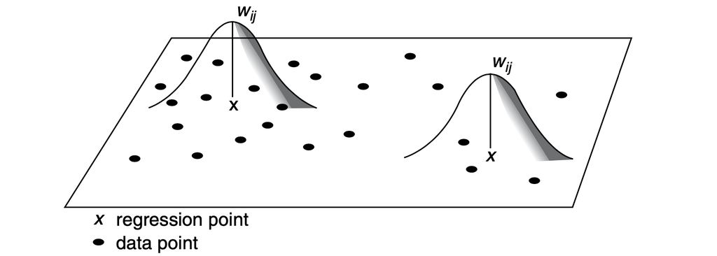

With fixed bandwidth $h$, $w_{ij}$ is as follows:
$$w_{ij} = \begin{cases}
e^{-0.5(\frac{distance_{ij}}{h})^2},\;\;\;\;\;if\;\;\;distance_{ij}\leq
h\\
\;\;\;\;\;\;\;\;\;\;\;\;\;\;\;\;\;0,\;\;\;\;\;if\;\;\;otherwise
\end{cases}$$
$Distance_{ij}$ is the distance between the regression point $i$ and data point $j$, and number of observations will vary around each point $i$, but the bandwidth distance $h$ will remain constant.

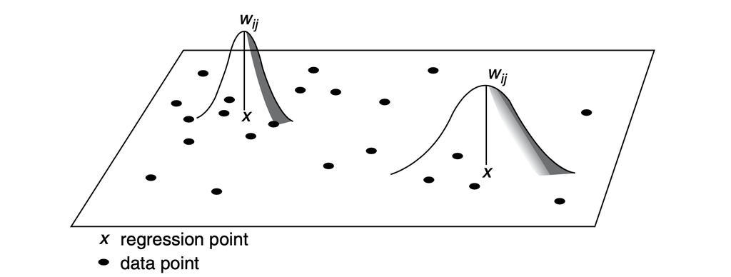

With adaptive bandwidth $h$, $w_{ij}$ is as follows :
$$w_{ij} = \begin{cases}
\Bigl[1-(\frac{distance_{ij}}{h})^2\Bigr]^2,\;\;\;\;\;if\;\;j\;\;is\;one\;of\;i's\;N\;nearest\;neighbors\\
\;\;\;\;\;\;\;\;\;\;\;\;\;\;\;\;\;\;\;\;\;\;\;\;\;\;0,\;\;\;\;\;if\;\;otherwise
\end{cases}$$
$Distance_{ij}$ is the distance between the regression point $i$ and data point $j$, and number of observations will remain constant around each point $i$, but the bandwidth distance $h$ will vary. As for us, adaptive bandwidth is more appropriate because our data varies across space.

### 2.4.5 Assumptions in GWR

Many of the assumptions in OLS–such as the normality of residuals, homoscedastiticty, the absence of multicollinearity, and the normal distribution of residuals–still need to be met for GWR. GWR builds a local regression equation for each feature in the dataset. When the value for an explanatory varially clusters spatially in a substantial way, we are still likely to have a problem. That is, the variable tells the same story at every location. We also may have a problem with multicollinearity when we have two or more variables that have similar patterns of clusters in a certain region. Likewise, We may run into problems if we use two variables which both have very high (or very low) values at all locations in a certain part of the study region. The condition number in the attribute table indicates when results are unstable due to local multicollinearity. To check this issue, we can look through the Cond.Number field from the GWR results attribute table, As a rule of thumb, multicollinearity issues likely arise for features with a condition number larger than 30, equal to Null, or equal to -1.7976931348623158e + 308.

### 2.4.6 GWR and P-Values

In a global model it is usual to test whether the parameter estimates are significantly different from zero. This can be accomplished with a t-test. The situation with GWR is a little more complex and is the subject of current research. As there is one set of parameters associated with each regression point, as well as one set of standard errors, there are potentially thousands of tests that would be required to determine whether parameters are locally significant. The assumption behind the tests means that if the 0.05 significance level is used, we would expect 5 tests in every 100 to be significant. With a 5 variable model estimated at 20,000 regression points, we would expect 5,000 of these tests to return a significant result. This is the problem raised by multiple testing.

## 2.5 Tools

In our assignment, we rely on the usual `tidyverse`, `sf`, and `tmap` packages in R. We also incorporate a number of spatial packages such as `sp`, `rgdal`, and `rgeos`. Most of our spatial regression work relies on `spdep` and `spgwr`. Importantly, we use the [recently-released `sfdep` package](https://sfdep.josiahparry.com/), which is basically a `tidy` version of the `spdep` package and allows us to incorporate `sf` objects. Finally, we use `lmtest`, `whitestrap`, and `tseries` for the Breusch-Pagan, White, and Jarque-Bera tests respectively.

## 2.6 Import and Prepare Data

As in Homework #1, we are completing this assignment in R (rather than using GeoDa and ArcGIS). Once again, we will read in the original shapefile of data and transform the relevant columns to produce the initial data that we need for our analysis.

```r
#reg_data = st_read('C:/Users/Nissim/Desktop/Fall 2022/Spat Stats/musa-500-hmwk-2/reg_data_files/Regression Data.shp')

#Min
reg_data = read_sf('C:/Users/Nissim/Desktop/Fall 2022/Spat Stats/musa-500-hmwk-2/data/Regression Data.shp')

#define a function to find zero values in columns

# This function applies log transformations to the relevant columns. It checks whether there are zero values in each column and then applies the appropriate log transformation accordingly.

col_zeros = function(a, b) {
                  pct_col_zeros = count(subset(st_drop_geometry(a), b != 0)) |>
                                      pull(n) / nrow(st_drop_geometry(a))
                  return(pct_col_zeros)
                  }
#apply function with case_when statement
#case_when is a vectorized function, while ifelse is not.
#running this with ifelse will result in all row values in the mutated column being the same.
reg_data = reg_data |>
            mutate(
                ln_med_h_val = case_when(col_zeros(reg_data, reg_data$MEDHVAL) == 1 ~ log(reg_data$MEDHVAL),
                                     TRUE ~ log(1 + reg_data$MEDHVAL)),
                   ln_pct_bach_more = case_when(col_zeros(reg_data, reg_data$PCTBACHMOR) == 1 ~ log(reg_data$PCTBACHMOR),
                                     TRUE ~ log(1 + reg_data$PCTBACHMOR)),
                   ln_n_bel_pov_100 = case_when(col_zeros(reg_data, reg_data$NBelPov100) == 1 ~ log(reg_data$NBelPov100),
                                     TRUE ~ log(1 + reg_data$NBelPov100)),
                   ln_pct_vacant = case_when(col_zeros(reg_data, reg_data$PCTVACANT) == 1 ~ log(reg_data$PCTVACANT),
                                     TRUE ~ log(1 + reg_data$PCTVACANT)),
                   ln_pct_singles = case_when(col_zeros(reg_data, reg_data$PCTSINGLES) == 1 ~ log(reg_data$PCTSINGLES),
                                     TRUE ~ log(1 + reg_data$PCTSINGLES)),
                  )
```

# 3 Results

## 3.1 Spatial Autocorrelation

### 3.1.1 Distribution of Median House Value

The map below displays the spatial distribution of median house value by census tract in Philadelphia.

```r
tmap_mode("plot")
```

```
## tmap mode set to plotting
```

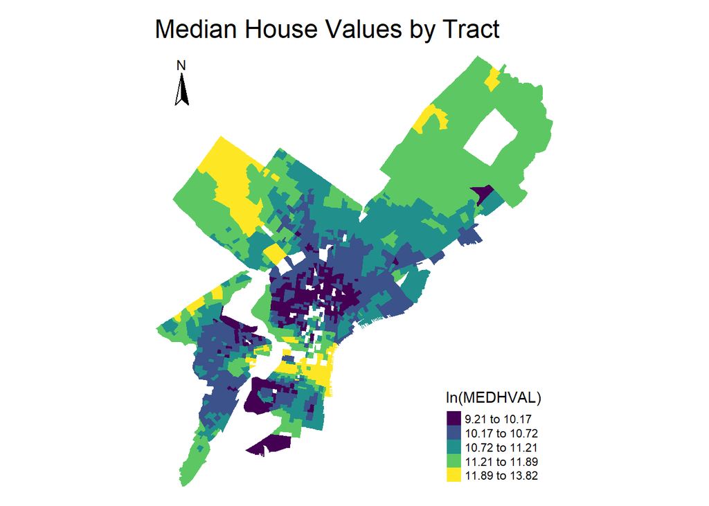

```r
tm_shape(reg_data) +
  tm_polygons(title = "ln(MEDHVAL)", col = "LNMEDHVAL", border.col = NA, border.alpha = 0, lwd = 0, palette = "viridis", style = "jenks") +
 # tm_shape(phl_city_lims) +
#  tm_borders(col = "grey", lwd = 5) +
  tm_compass(position = c("left", "top")) +
  tm_layout(main.title = "Median House Values by Tract",
            legend.position = c("right", "bottom"),
            frame = FALSE)
```

### 3.1.2 Global Moran’s I

Below, we calculate a global Moran’s I value and analyze it using a Monte Carlo approach, which compares our calculated Moran’s I to 999 random permutations.

First, we’ll prepare a weight matrix based on Queen neighbors.[^4]

```r
# create our queen weight matrix
# reg_data_nb = reg_data |>
        #              spdep::poly2nb(row.names = reg_data$POLY_ID)

# grab geometry
reg_data = reg_data |>
              mutate(nb_geom = st_geometry(reg_data), #geoms for poly2nb
                     nb = st_contiguity(nb_geom), # generate neighbors
                     weights = st_weights(nb)) # weight matrices from neighbors

summary(reg_data$nb)
```

```
## Neighbour list object:
## Number of regions: 1720
## Number of nonzero links: 10526
## Percentage nonzero weights: 0.3558004
## Average number of links: 6.119767
## Link number distribution:
##
##   1   2   3   4   5   6   7   8   9  10  11  12  13  14  15  16  18  27
##   4  16  52 175 348 493 344 177  62  28  10   4   2   1   1   1   1   1
## 4 least connected regions:
## 441 708 1391 1665 with 1 link
## 1 most connected region:
## 1636 with 27 links
```

We can visualize the connections between neighbors based on the weight matrix that we’ve connected:

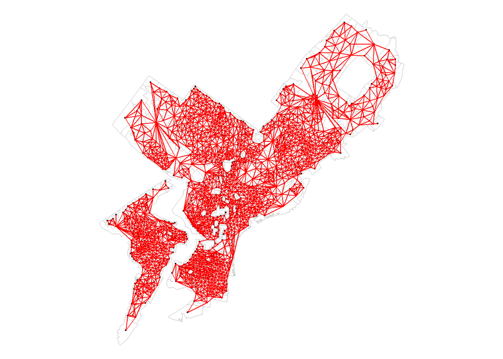

```r
reg_data_lines = nb2lines(reg_data$nb,
                          coords = st_centroid(reg_data$geometry),
                          as_sf = TRUE)

tm_shape(reg_data) +
  tm_borders(col = "grey", lwd = 0.5) +
tm_shape(reg_data) +
  tm_dots() +
tm_shape(reg_data_lines) +
  tm_lines(col = "red") +
tm_layout(frame = FALSE)
```

Now we can apply the weight matrix that to calculate the global Moran’s I.

```r
# Global Moran's I

# now use that weight matrix to calculate global moran's i for MEDHVAL

global_moran(reg_data$ln_med_h_val, reg_data$nb, reg_data$weights)$`I`
```

```
## [1] 0.7935638
```

Having calculated a global Moran’s I, we’ll use a Monte Carlo approach to test whether our global Moran’s I is statistically significant. If the null hypothesis is true, then the probability of drawing the observed data is the same as any other permutation of the $i$’s amongst the polygons. Thus, if $m$ is the number of simulated Moran’s I values exceeding the observed one, and $M$ is the total number of simulations, then the probability of getting the observed Moran’s I or greater is

$$p = \frac{m+1}{M+1}$$

```r
# reshuffling test w 999 permutations
# present Moran's I value, histogram of Moran's I values with all permutations, and p-value

moranMC = global_moran_perm(reg_data$ln_med_h_val, reg_data$nb, reg_data$weights, alternative = "two.sided", 999)

moranMC
```

```
##
##  Monte-Carlo simulation of Moran I
##
## data:  x
## weights: listw
## number of simulations + 1: 1000
##
## statistic = 0.79356, observed rank = 1000, p-value < 2.2e-16
## alternative hypothesis: two.sided
```

Here we visualize the randomly permuted values from the Monte Carlo test.

[figure not shown]

```r
#draws a histogram of our randomly permuted values
# and adds a red line for our actual moran's i

moranMCres = moranMC$res |>
              as.data.frame()

colnames(moranMCres) = "col1"

ggplot(moranMCres) +
  geom_histogram(aes(col1), bins = 100) +
  geom_vline(xintercept = moranMC$statistic, col = "red") +
  labs(title = "Histogram of MoranMCres",
       x = "moranMCres",
       y = "Frequency") +
  theme_minimal() +
  theme(plot.title = element_text(hjust = 0.5))
```

Additional confirmation of the significance of our Moran’s I value can be found by plotting the relationship between ln_med_h_val of the block groups and their neighbors. If there were no relationship between block group observations and those of their neighbors, we would not see a clear pattern in the plot below. However, we observe that this is not the case.

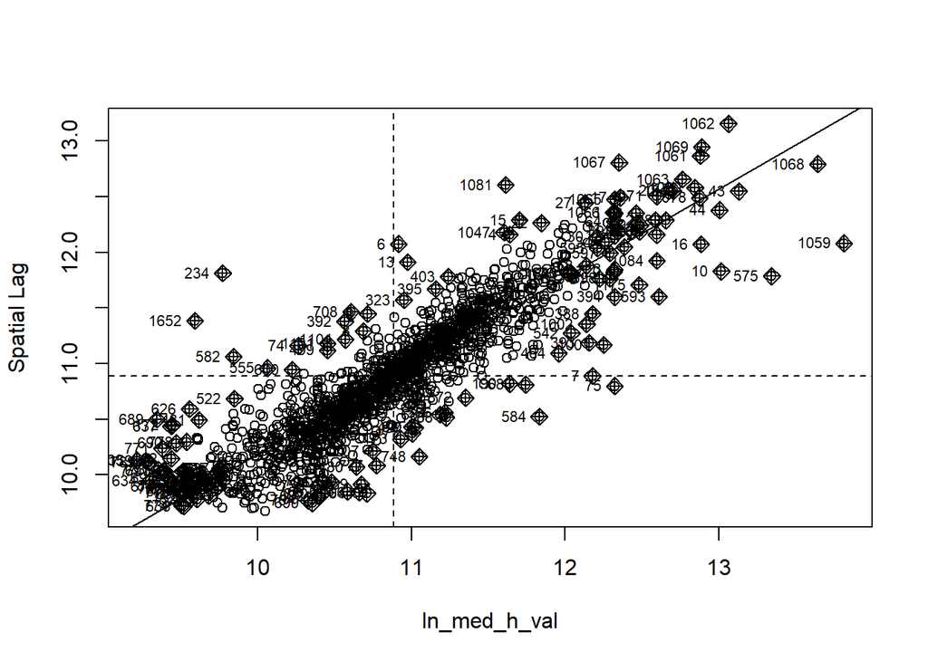

```r
moran.plot(reg_data$ln_med_h_val, nb2listw(reg_data$nb),
           xlab = "ln_med_h_val",
            ylab = "Spatial Lag")
```

### 3.1.3 Local Moran’s I

The `local_moran` function in `sfdep` allows us to compute LISA statistics for each block group. This function generates the Local Moran statistic as `ii`. We might also be interested in `var_ii`, which tells us how much each block group’s Local Moran Statistic varies from the global mean, and `p_ii`, which indicates whether the Local Moran Statistic can be considered statistically significant.

```r
# Local Moran's I

# local Moran's I analysis with queen weight matrix; print results

lisa = local_moran(reg_data$ln_med_h_val, reg_data$nb, reg_data$weights, nsim = 999)

head(lisa)
```

```
##          ii           eii       var_ii     z_ii         p_ii p_ii_sim
## 1 5.3518753 -0.0614898509 1.3364064928 4.682718 2.830954e-06    0.002
## 2 4.4121912 -0.0073062459 0.7118931178 5.238000 1.623261e-07    0.002
## 3 3.5006316  0.0411214557 0.7642634601 3.957246 7.581882e-05    0.002
## 4 2.4444508  0.0235953540 0.2490908184 4.850539 1.231264e-06    0.002
## 5 1.8834699  0.0273707902 0.6441148595 2.312701 2.073908e-02    0.046
## 6 0.0995037  0.0001556868 0.0009613705 3.204157 1.354586e-03    0.002
##   p_folded_sim    skewness    kurtosis      mean    median     pysal
## 1        0.001  0.07783226  0.16297614 High-High High-High High-High
## 2        0.001  0.30980196  0.51776442 High-High High-High High-High
## 3        0.001  0.11421600  0.09571973 High-High High-High High-High
## 4        0.001  0.19659418  0.29340205 High-High High-High High-High
## 5        0.023  0.42558089  0.57809875 High-High High-High High-High
## 6        0.001 -0.02400010 -0.01847904 High-High High-High High-High
```

Now we can examine the local Moran’s I values to see if there is significant spatial autocorrelation. Mapping the p-values that we’ve just calculated, it appears that we have statistically significant (p < 0.05) clustering in parts of northwest, northeast, north, and west Philadelphia.

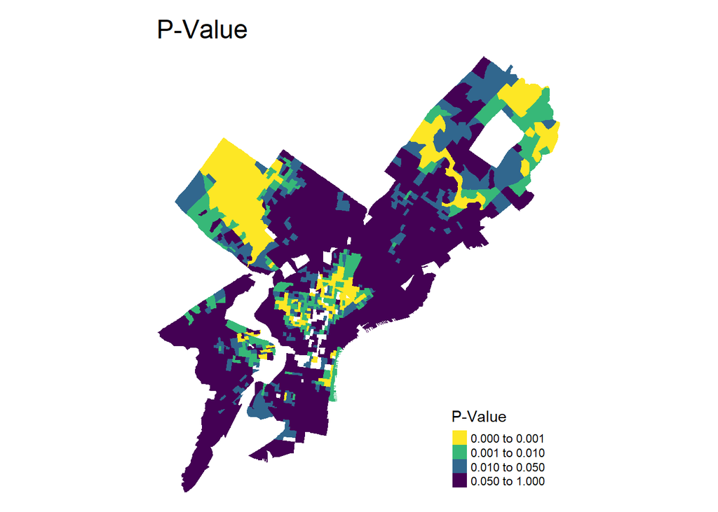

```r
# first we need to bind the lisa dataframe to our reg_data dataframe

reg_data = cbind(reg_data, lisa)

tm_shape(reg_data) +
  tm_fill(style = "fixed",
          col = "p_ii",
          breaks = c(0,0.001, 0.01, 0.05, 1),
          palette = '-viridis',
          title = "P-Value") +
  #tm_borders(col = "white",
   #          lwd = 0.05) +
  tm_layout(frame = FALSE, main.title = "P-Value")
```

We can now visualize statistically significant clustering throughout the city, which the local Moran’s I calculation groups into High-High, High-Low, Low-High, and Low-Low clusters. (We will also exclude clusters for which p > 0.05.)

Based on our map, it appears that there are significant High-High clusters in northwest and northeast Philadelphia, as well as some small neighborhoods near Old City, along City Line Avenue, and near the Navy Yard in south Philadelphia. Significant Low-Low clusters are also found in North Philadelphia, parts of West Philadelphia, and small scattered sites near Grays Ferry.

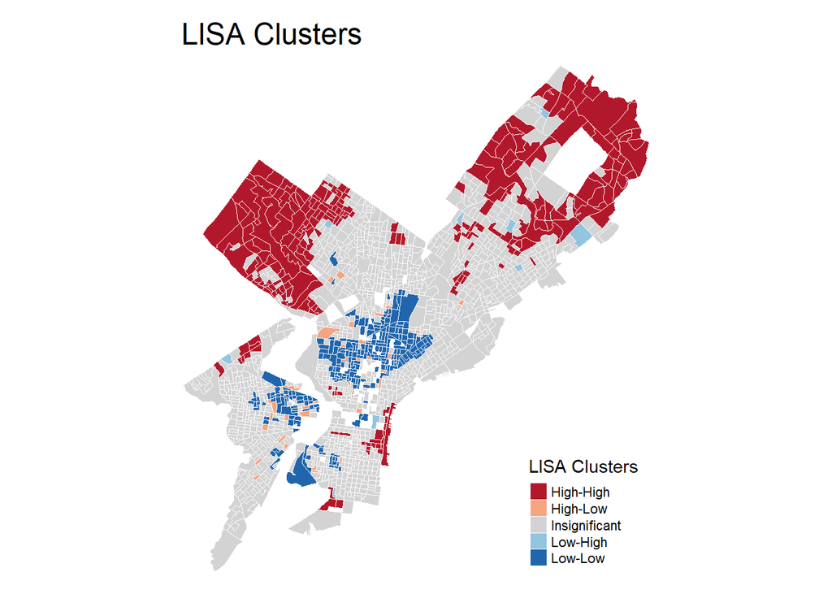

```r
reg_data = reg_data |>
            mutate(
                  mean = as.character(mean),
                  lisa_map = case_when(
                                  p_ii < 0.05 ~ mean,
                                  TRUE ~ "Insignificant"
                                )
                  )

pal = c("#B2182B", "#F4A582", "lightgrey", "#92C5DE", "#2166AC")

tm_shape(reg_data) +
  tm_fill(col = "lisa_map", palette = pal, title = "LISA Clusters")+
  tm_borders(col = "white", lwd = 0.05) +
  tm_layout(frame = FALSE, main.title = "LISA Clusters")
```

## 3.2 OLS Regression and Assumptions

### 3.2.1 OLS Output

Our model regressed the log of median house values (ln_med_h_val) on four predictors, namely,

1. the percents of individual with bachelor’s degrees or higher (PCBACHMORE),
2. the number of households living below the poverty line (LNNBELPOV),
3. the percent of vacant houses (PCTVACANT), and
4. the percent of single houses units (PCTSINGLES).

The output of our OLS regression indicates that all four predictors are statistically significant; the p-value for the F-statistic is less than 0.05, as are the individual p-values for each predictor. Additionally, our OLS model explains more than 60% of the variance of LNMEDHVAL ($R^2$ is 0.6623 and the Adjusted $R^2$ is 0.6615). LNNBELPOV and PCTVACANT are negatively associated with LNMEDHVAL, while PCTBACHMOR and PCTSINGLES are positively associated with LNMEDHVAL.

```r
# OLS Regression

reg = lm(formula=ln_med_h_val ~ ln_n_bel_pov_100 + PCTBACHMOR + PCTSINGLES + PCTVACANT, data = reg_data)

summary(reg)
```

```
##
## Call:
## lm(formula = ln_med_h_val ~ ln_n_bel_pov_100 + PCTBACHMOR + PCTSINGLES +
##     PCTVACANT, data = reg_data)
##
## Residuals:
##      Min       1Q   Median       3Q      Max
## -2.25825 -0.20391  0.03822  0.21744  2.24347
##
## Coefficients:
##                    Estimate Std. Error t value Pr(>|t|)
## (Intercept)      11.1137661  0.0465330 238.836  < 2e-16 ***
## ln_n_bel_pov_100 -0.0789054  0.0084569  -9.330  < 2e-16 ***
## PCTBACHMOR        0.0209098  0.0005432  38.494  < 2e-16 ***
## PCTSINGLES        0.0029769  0.0007032   4.234 2.42e-05 ***
## PCTVACANT        -0.0191569  0.0009779 -19.590  < 2e-16 ***
## ---
## Signif. codes:  0 '***' 0.001 '**' 0.01 '*' 0.05 '.' 0.1 ' ' 1
##
## Residual standard error: 0.3665 on 1715 degrees of freedom
## Multiple R-squared:  0.6623, Adjusted R-squared:  0.6615
## F-statistic: 840.9 on 4 and 1715 DF,  p-value: < 2.2e-16
```

In order to compare our OLS model to the other models generated later in this assignment, we will run a log likelihood test. We will return to these results later.

```r
logLik(reg)
```

[output not shown]

To test for heteroscedasticity, we will run three tests:

1. the Breusch-Pagan test

```r
bptest(reg, studentize = FALSE)
```

```
##
##  Breusch-Pagan test
##
## data:  reg
## BP = 68.649, df = 2, p-value = 1.239e-15
```

2. the Koenker-Bassett test (also known as the Studentized Breusch-Pagan test)

```r
bptest(reg, studentize = TRUE)
```

```
##
##  studentized Breusch-Pagan test
##
## data:  reg
## BP = 20.892, df = 2, p-value = 2.906e-05
```

3. the White test

```r
white_test(reg)
```

```
## White's test results
##
## Null hypothesis: Homoskedasticity of the residuals
## Alternative hypothesis: Heteroskedasticity of the residuals
## Test Statistic: 52.48
## P-value: 0
```

In all three cases, p < 0.05, indicating a problem with heteroscedasticity in our data.

Finally, we will run the Jarque-Bera test to assess whether the residuals of our regression are normal. Here, too, p < 0.05, indicating that our residuals are not normally distributed.

```r
jarque.bera.test(reg$residuals)
```

```
##
##  Jarque Bera Test
##
## data:  reg$residuals
## X-squared = 2012.4, df = 2, p-value < 2.2e-16
```

### 3.2.2 Scatterplot of Residuals

Here, we’ll generate standardized residuals, which are OLS Model residuals divided by an estimate of their standard deviation. We can evaluate these standardized residuals to consider spatial autocorrelation in our OLS model by comparing them to their spatial lag.

First, we plot standardized residuals against the spatially lagged residuals. We see strong correlation, which is confirmed by the output of the linear model: $\rho$ (the slope of our linear model in the plot) is 0.732, indicating strong spatial autocorrelation in our OLS model.

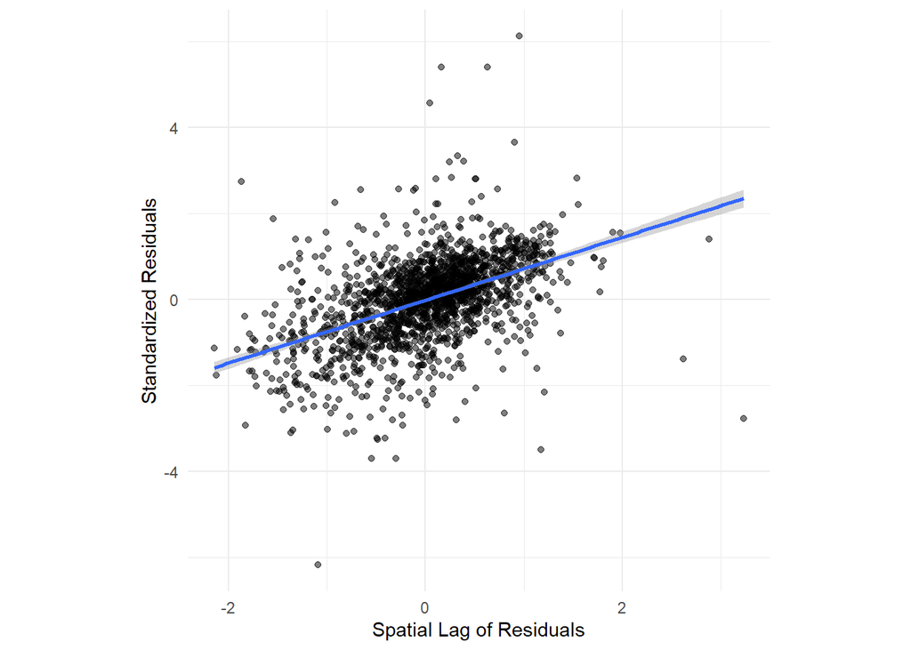

```r
reg_data = reg_data |>
              mutate(stand_resids = rstandard(reg),
                     spatial_lag = st_lag(stand_resids,
                                             nb,
                                             weights))

ggplot(reg_data, aes(x = spatial_lag, y = stand_resids)) +
  geom_point(alpha = 0.5) +
  geom_smooth(method = 'lm') +
  labs(x = "Spatial Lag of Residuals",
       y = "Standardized Residuals") +
  theme_minimal() +
  theme(aspect.ratio = 1)
```

```r
lm(formula =  stand_resids ~ spatial_lag, data = reg_data)
```

```
##
## Call:
## lm(formula = stand_resids ~ spatial_lag, data = reg_data)
##
## Coefficients:
## (Intercept)  spatial_lag
##    -0.01281      0.73235
```

Further confirmation of this comes from mapping our standardized residuals, which appear to cluster in northwest, northeast, and north Philadelphia, as well as possibly downtown.

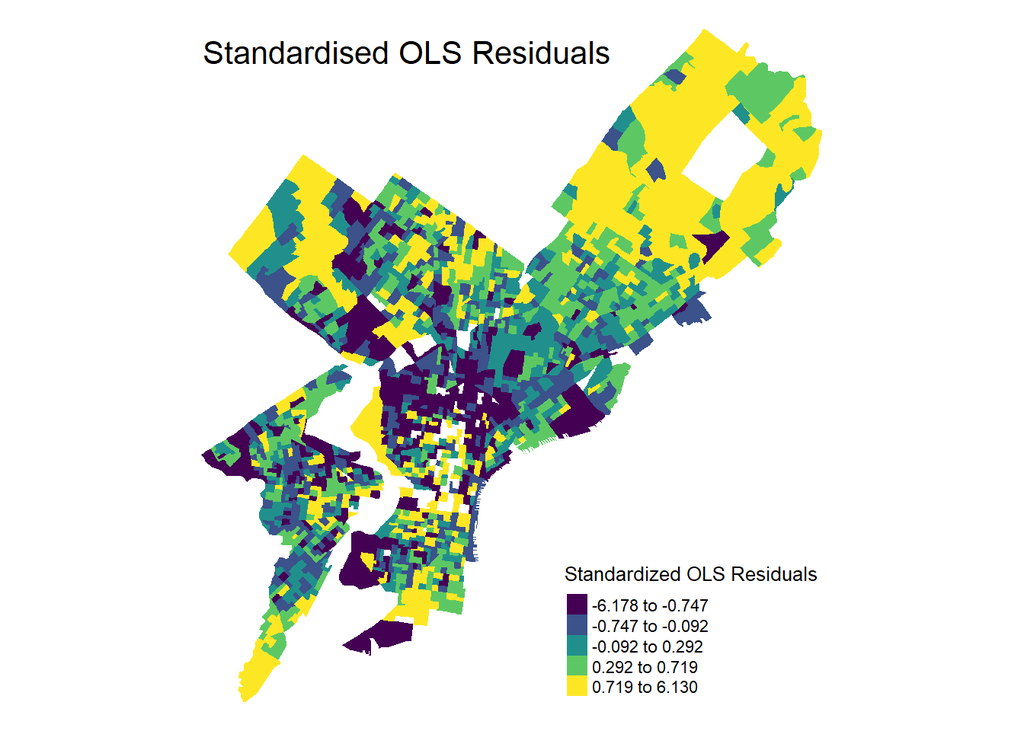

```r
tm_shape(reg_data)+
  tm_fill(col = 'stand_resids',
          style = 'quantile',
          title = 'Standardized OLS Residuals',
          palette ='viridis',
          midpoint = 0)+
  tm_layout(frame = FALSE,
            title = 'Standardised OLS Residuals')
```

However, a visual assessment is not sufficient, and we will test the presence of spatial autocorrelation in two ways: 1) by regressing residuals on their queen neighbors, and 2) by looking at the Moran’s I of the residuals.

First, let’s regress the OLS standardized residuals on the spatial lag of the OLS residuals (i.e., OLS residuals at the queen neighbors).

```r
resids_lm = lm(formula = stand_resids ~ spatial_lag, data = reg_data)

summary(resids_lm)
```

[output not shown]

### 3.2.3 Moran’s I Significance

Once again, we can use the Monte Carlo simulation to generate a Moran’s I statistics and a pseudo p-value.

```r
global_moran_perm(reg_data$stand_resids, reg_data$nb, reg_data$weights, alternative = "two.sided", 999)
```

```
##
##  Monte-Carlo simulation of Moran I
##
## data:  x
## weights: listw
## number of simulations + 1: 1000
##
## statistic = 0.20532, observed rank = 1000, p-value < 2.2e-16
## alternative hypothesis: two.sided
```

It is strongly apparent that spatial autocorrelation exists among the regression residuals of the OLS Model. The p-value is very small, indicating that Moran’s I is significant. Because there’s clearly spatial autocorrelation in our OLS residuals, the OLS Model is inappropriate and we need to consider another method. Next, we will attempt to run the spatial lag model, the spatial error model, and geographically weighted regression.

[figure not shown]

```r
moran.plot(reg_data$stand_resids, nb2listw(reg_data$nb),
           xlab = "Standardized Residuals",
            ylab = "Spatial Lag")
```

## 3.3 Spatial Lag and Spatial Error Regression

### 3.3.1 Spatial Lag Regression Results

1. Present results of Spatial Lag regression (call this Table 2)
1. Talk about the W_LNMEDHVAL term in the spatial lag regression output. State whether it is significant, and how the results can be interpreted.
2. Are the remaining terms (i.e., the predictors LNNBELPOV, PCTBACHMOR, PCTSINGLES, and PCTVACANT) in the model significant?
1. Compare these results to OLS results.
3. State whether, based on the Breusch-Pagan test, the spatial lag regression residuals are still heteroscedastic.
4. Compare the Spatial Lag regression and OLS regression models based on the Akaike Information Criterion/Schwarz Criterion, the Log Likelihood, and the Likelihood Ratio Test.

Here we have generated a spatial lag regression model and summarized the output. The coefficient of spatial lag $\rho = 0.65$ and is significant (p < 0.05), indicating that a one unit increase in the spatial lag of LNMEDHVAL is associated with a 0.65 unit increase in LNMEDHVAL at a given location. Furthermore, as in our OLS model, all four of our predictors have p < 0.05, meaning that they are significant.

```r
spatial_lag_reg = lagsarlm(formula = ln_med_h_val ~ ln_n_bel_pov_100 + PCTBACHMOR + PCTSINGLES + PCTVACANT, data = reg_data, nb2listw(reg_data$nb))

sumslr = summary(spatial_lag_reg)

sumslr
```

[output not shown]

To test for heteroscedasticity, we will once again run two of the three tests run above. In both cases, p < 0.05, indicating problems with heteroscedasticity in our spatial lag model.

1. the Breusch-Pagan test

```r
bptest.Sarlm(spatial_lag_reg, studentize = FALSE)
```

```
##
##  Breusch-Pagan test
##
## data:
## BP = 34.725, df = 2, p-value = 2.881e-08
```

2. the Koenker-Bassett test (also known as the Studentized Breusch-Pagan test)

```r
bptest.Sarlm(spatial_lag_reg, studentize = TRUE)
```

```
##
##  studentized Breusch-Pagan test
##
## data:
## BP = 11.945, df = 2, p-value = 0.002548
```

Likewise, we again run the Jarque-Bera test to assess whether the residuals of our regression are normal. Here, too, p < 0.05, indicating an non-normality in the distribution of the residuals of our spatial lag model.

```r
jarque.bera.test(spatial_lag_reg$residuals)
```

```
##
##  Jarque Bera Test
##
## data:  spatial_lag_reg$residuals
## X-squared = 1360.1, df = 2, p-value < 2.2e-16
```

Next, we will consider spatial autocorrelation in our model. Visually, it appears that the residuals from our spatial lag model show less autocorrelation than in our OLS model.

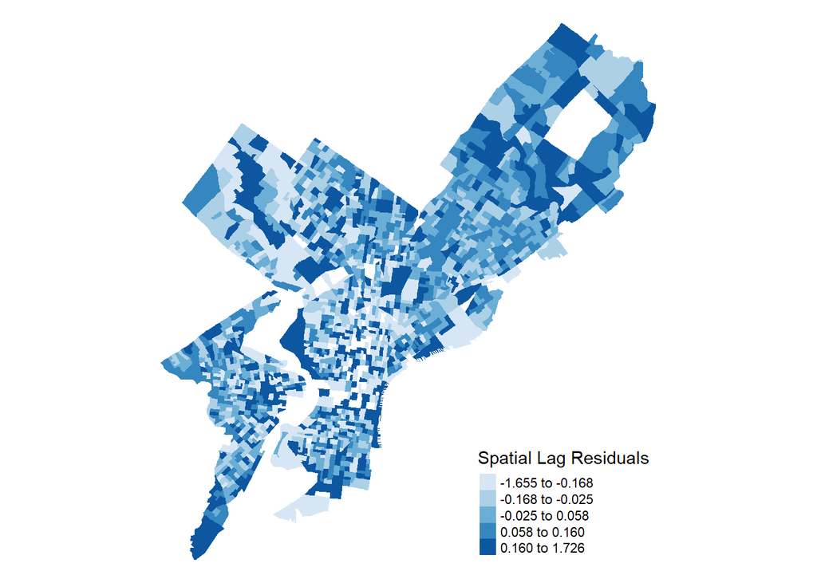

```r
reg_data = reg_data |>
              mutate(
                spatial_lag_resids = lagsarlm(formula = ln_med_h_val ~ ln_n_bel_pov_100 + PCTBACHMOR + PCTSINGLES + PCTVACANT, data = reg_data, nb2listw(reg_data$nb))$residuals
              )

tm_shape(reg_data)+
  tm_fill(col = 'spatial_lag_resids',
          style = 'quantile',
          title = 'Spatial Lag Residuals',
          palette ='Blues',
          midpoint = 0)+
  tm_layout(frame = FALSE)
```

Running a Monte Carlo simulation for the global Moran’s I of the spatial lag residuals,

```r
global_moran_perm(spatial_lag_reg$residuals, reg_data$nb, reg_data$weights, alternative = "two.sided", 999)
```

```
##
##  Monte-Carlo simulation of Moran I
##
## data:  x
## weights: listw
## number of simulations + 1: 1000
##
## statistic = -0.041474, observed rank = 2, p-value = 0.004
## alternative hypothesis: two.sided
```

```r
# Moran's I for spatial lag model

# once again, run moran's I for the spatial lag residuals; test w 999 permutations
# print scatterplot & summary table of significance test
```

Lastly, we can compare our spatial lag model to the previous OLS model using both the log likelihood ratio and the AIC.

Additionally, using the likelihood ratio stest, we can see that the p-value < 0.05, so we can reject $H_0$ and state that the spatial lag model is better than the OLS model.

```r
LR.Sarlm(spatial_lag_reg, reg) #Here lagreg is the SL output; reg is the OLS output
```

```
##
##  Likelihood ratio for spatial linear models
##
## data:
## Likelihood ratio = 237.47, df = 1, p-value < 2.2e-16
## sample estimates:
## Log likelihood of spatial_lag_reg             Log likelihood of reg
##                         -598.9141                         -717.6489
```

[output not shown]

### 3.3.2 Spatial Error Regression Results

```r
spatial_error_reg = errorsarlm(formula = ln_med_h_val ~ ln_n_bel_pov_100 + PCTBACHMOR + PCTSINGLES + PCTVACANT,
                               data = reg_data,
                               nb2listw(reg_data$nb))

summary(spatial_lag_reg)
```

[output not shown]

```r
LR.Sarlm(spatial_error_reg, reg) #Here lagreg is the SL output; reg is the OLS output
```

```
##
##  Likelihood ratio for spatial linear models
##
## data:
## Likelihood ratio = 173.5, df = 1, p-value < 2.2e-16
## sample estimates:
## Log likelihood of spatial_error_reg               Log likelihood of reg
##                           -630.8990                           -717.6489
```

To test for heteroscedasticity, we will once again run two of the three tests run above:

1. the Breusch-Pagan test

```r
bptest.Sarlm(spatial_error_reg, studentize = FALSE)
```

```
##
##  Breusch-Pagan test
##
## data:
## BP = 19.75, df = 2, p-value = 5.144e-05
```

2. the Koenker-Bassett test (also known as the Studentized Breusch-Pagan test)

```r
bptest.Sarlm(spatial_error_reg, studentize = TRUE)
```

```
##
##  studentized Breusch-Pagan test
##
## data:
## BP = 7.1133, df = 2, p-value = 0.02853
```

And, again, the Jarque-Bera test to assess whether the residuals of our regression are normal.

```r
jarque.bera.test(spatial_error_reg$residuals)
```

```
##
##  Jarque Bera Test
##
## data:  spatial_error_reg$residuals
## X-squared = 1263.9, df = 2, p-value < 2.2e-16
```

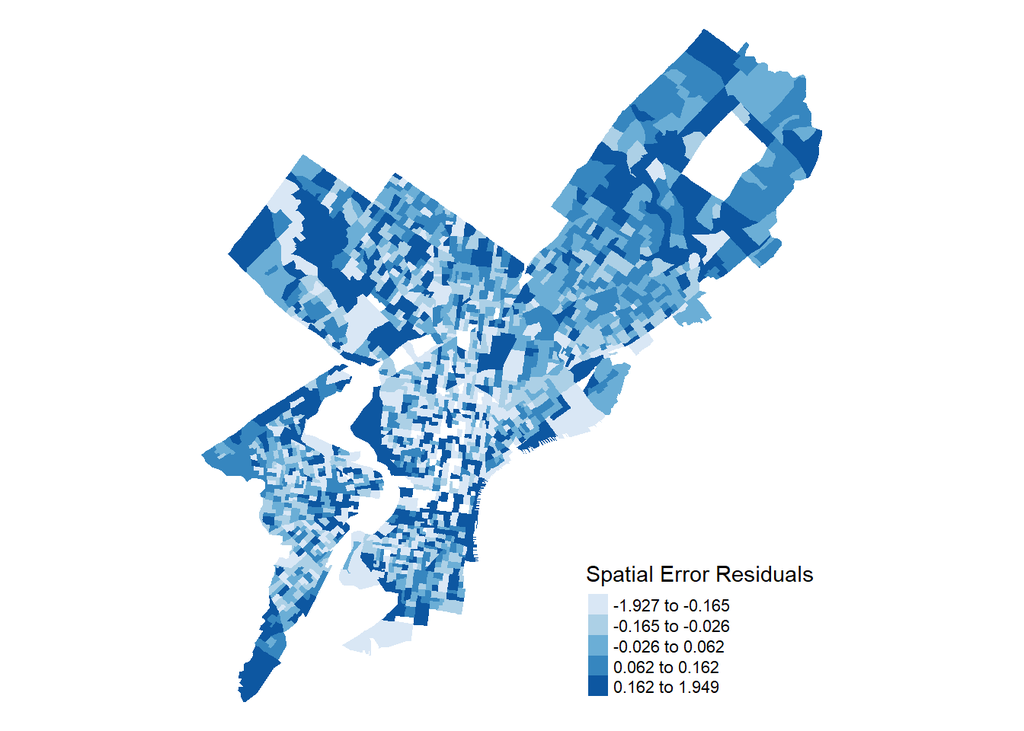

```r
reg_data = reg_data |>
              mutate(
                spatial_error_resids = errorsarlm(formula = ln_med_h_val ~ ln_n_bel_pov_100 + PCTBACHMOR + PCTSINGLES + PCTVACANT, data = reg_data, nb2listw(reg_data$nb))$residuals
              )

tm_shape(reg_data)+
  tm_fill(col = 'spatial_error_resids',
          style = 'quantile',
          title = 'Spatial Error Residuals',
          palette ='Blues',
          midpoint = 0)+
  tm_layout(frame = FALSE)
```

```r
global_moran_perm(spatial_error_reg$residuals, reg_data$nb, reg_data$weights, alternative = "two.sided", 999)
```

```
##
##  Monte-Carlo simulation of Moran I
##
## data:  x
## weights: listw
## number of simulations + 1: 1000
##
## statistic = -0.031944, observed rank = 17, p-value = 0.034
## alternative hypothesis: two.sided
```

```r
# Moran's I for spatial error model

# once again, run moran's I for the spatial error residuals; test w 999 permutations
# print scatterplot & summary table of significance test
```

## 3.4 Geographically Weighted Regression

### 3.4.1 GWR Results

1. Present GWR results from the _supp table (call this Table 4)
1. Compare the (overall) R-squared of the GWR regression with the R-squared of the OLS regression. State which regression method seems to be doing a better job of explaining the variance in the dependent variable.
2. Compare the Akaike Information Criteria of GWR with those of OLS, Spatial Lag and Spatial Error models. Which model seems to be doing a better job based on that (remember, the lower the Akaike Information Criterion, the better the fit).

Here we create an adaptive bandwidth.

```r
adapt_bandwidth_est = GWmodel::bw.gwr(formula = ln_med_h_val ~ ln_n_bel_pov_100 + PCTBACHMOR + PCTSINGLES + PCTVACANT,
                                data = reg_data |> sf::as_Spatial(),
                                approach = 'AIC',
                                kernel = 'gaussian',
                                adaptive = TRUE)
```

```
## Take a cup of tea and have a break, it will take a few minutes.
##           -----A kind suggestion from GWmodel development group
## Adaptive bandwidth (number of nearest neighbours): 1070 AICc value: 1334.777
## Adaptive bandwidth (number of nearest neighbours): 669 AICc value: 1280.776
## Adaptive bandwidth (number of nearest neighbours): 420 AICc value: 1214.742
## Adaptive bandwidth (number of nearest neighbours): 267 AICc value: 1129.01
## Adaptive bandwidth (number of nearest neighbours): 171 AICc value: 1026.228
## Adaptive bandwidth (number of nearest neighbours): 113 AICc value: 940.2137
## Adaptive bandwidth (number of nearest neighbours): 76 AICc value: 863.4234
## Adaptive bandwidth (number of nearest neighbours): 54 AICc value: 803.0275
## Adaptive bandwidth (number of nearest neighbours): 39 AICc value: 745.4633
## Adaptive bandwidth (number of nearest neighbours): 31 AICc value: 712.1281
## Adaptive bandwidth (number of nearest neighbours): 25 AICc value: 686.4389
## Adaptive bandwidth (number of nearest neighbours): 22 AICc value: 676.2034
## Adaptive bandwidth (number of nearest neighbours): 19 AICc value: 670.9108
## Adaptive bandwidth (number of nearest neighbours): 18 AICc value: 667.0847
## Adaptive bandwidth (number of nearest neighbours): 16 AICc value: 663.0365
## Adaptive bandwidth (number of nearest neighbours): 16 AICc value: 663.0365
```

```r
adapt_bandwidth_est = gwr.sel(formula=ln_med_h_val ~ ln_n_bel_pov_100 + PCTBACHMOR + PCTSINGLES + PCTVACANT,
                              data = reg_data |> sf::as_Spatial(),
                              method = "aic",
                              adapt = TRUE)
```

```
## Bandwidth: 0.381966 AIC: 1278.726
## Bandwidth: 0.618034 AIC: 1334.073
## Bandwidth: 0.236068 AIC: 1209.53
## Bandwidth: 0.145898 AIC: 1115.876
## Bandwidth: 0.09016994 AIC: 1007.348
## Bandwidth: 0.05572809 AIC: 910.4307
## Bandwidth: 0.03444185 AIC: 821.2906
## Bandwidth: 0.02128624 AIC: 737.6009
## Bandwidth: 0.01315562 AIC: 681.6086
## Bandwidth: 0.008130619 AIC: 660.8787
## Bandwidth: 0.005024999 AIC: 714.2598
## Bandwidth: 0.009856269 AIC: 667.0857
## Bandwidth: 0.006944377 AIC: 667.59
## Bandwidth: 0.008427569 AIC: 661.757
## Bandwidth: 0.007677515 AIC: 663.6788
## Bandwidth: 0.008171309 AIC: 660.931
## Bandwidth: 0.00805268 AIC: 661.144
## Bandwidth: 0.008130619 AIC: 660.8787
```

Here we create a fixed bandwidth.

```r
fixed_bandwidth_est = gwr.sel(formula=ln_med_h_val ~ ln_n_bel_pov_100 + PCTBACHMOR + PCTSINGLES + PCTVACANT,
                              data = reg_data |> sf::as_Spatial(),
                              method = "aic",
                              adapt = FALSE)
```

[output not shown]

```r
fixed_bandwidth_est
```

```
## [1] 2863.505
```

Here we run a basic GWR with an adaptive bandwidth.

```r
gwrmodel_adaptive = gwr(formula = ln_med_h_val ~ ln_n_bel_pov_100 + PCTBACHMOR + PCTSINGLES + PCTVACANT,
                        data = reg_data |> sf::as_Spatial(),
                        adapt = adapt_bandwidth_est, #adaptive bandwidth determined by proportion of observations accounted for
                        gweight = gwr.Gauss,
                        se.fit = TRUE, #to return local standard errors
                        hatmatrix = TRUE)

gwrmodel_adaptive
```

```
## Call:
## gwr(formula = ln_med_h_val ~ ln_n_bel_pov_100 + PCTBACHMOR +
##     PCTSINGLES + PCTVACANT, data = sf::as_Spatial(reg_data),
##     gweight = gwr.Gauss, adapt = adapt_bandwidth_est, hatmatrix = TRUE,
##     se.fit = TRUE)
## Kernel function: gwr.Gauss
## Adaptive quantile: 0.008130619 (about 13 of 1720 data points)
## Summary of GWR coefficient estimates at data points:
##                        Min.    1st Qu.     Median    3rd Qu.       Max.  Global
## X.Intercept.      9.6727001 10.7142952 10.9542194 11.1741864 12.0831379 11.1138
## ln_n_bel_pov_100 -0.2365328 -0.0733584 -0.0401192 -0.0126662  0.0948799 -0.0789
## PCTBACHMOR        0.0010974  0.0101382  0.0149281  0.0202191  0.0347274  0.0209
## PCTSINGLES       -0.0249715 -0.0075552 -0.0016627  0.0042280  0.0143341  0.0030
## PCTVACANT        -0.0317416 -0.0142387 -0.0089603 -0.0035771  0.0167916 -0.0192
## Number of data points: 1720
## Effective number of parameters (residual: 2traceS - traceS'S): 360.5225
## Effective degrees of freedom (residual: 2traceS - traceS'S): 1359.477
## Sigma (residual: 2traceS - traceS'S): 0.276227
## Effective number of parameters (model: traceS): 257.9061
## Effective degrees of freedom (model: traceS): 1462.094
## Sigma (model: traceS): 0.2663572
## Sigma (ML): 0.2455771
## AICc (GWR p. 61, eq 2.33; p. 96, eq. 4.21): 660.8787
## AIC (GWR p. 96, eq. 4.22): 308.7987
## Residual sum of squares: 103.73
## Quasi-global R2: 0.8479231
```

Here we run a basic GWR with a fixed bandwidth.

```r
# Perform a basic GWR
gwrmodel_fixed = gwr(formula = ln_med_h_val ~ ln_n_bel_pov_100 + PCTBACHMOR + PCTSINGLES + PCTVACANT,
              data = reg_data |> sf::as_Spatial(),
              bandwidth = fixed_bandwidth_est, #adaptive bandwidth determined by proportion of observations accounted for
              gweight = gwr.Gauss,
              se.fit = TRUE, #to return local standard errors
              hatmatrix = TRUE)

gwrmodel_fixed
```

```
## Call:
## gwr(formula = ln_med_h_val ~ ln_n_bel_pov_100 + PCTBACHMOR +
##     PCTSINGLES + PCTVACANT, data = sf::as_Spatial(reg_data),
##     bandwidth = fixed_bandwidth_est, gweight = gwr.Gauss, hatmatrix = TRUE,
##     se.fit = TRUE)
## Kernel function: gwr.Gauss
## Fixed bandwidth: 2863.505
## Summary of GWR coefficient estimates at data points:
##                        Min.    1st Qu.     Median    3rd Qu.       Max.  Global
## X.Intercept.      9.9111144 10.7328953 10.9397247 11.1639817 14.1200886 11.1138
## ln_n_bel_pov_100 -0.4449947 -0.0737759 -0.0433086 -0.0171177  0.1491675 -0.0789
## PCTBACHMOR       -0.0860921  0.0118751  0.0168151  0.0213557  0.0306660  0.0209
## PCTSINGLES       -0.0238339 -0.0073896 -0.0025703  0.0040499  0.0190000  0.0030
## PCTVACANT        -0.0469927 -0.0137377 -0.0088798 -0.0038448  0.0778877 -0.0192
## Number of data points: 1720
## Effective number of parameters (residual: 2traceS - traceS'S): 346.7158
## Effective degrees of freedom (residual: 2traceS - traceS'S): 1373.284
## Sigma (residual: 2traceS - traceS'S): 0.2785303
## Effective number of parameters (model: traceS): 255.6016
## Effective degrees of freedom (model: traceS): 1464.398
## Sigma (model: traceS): 0.2697262
## Sigma (ML): 0.2488791
## AICc (GWR p. 61, eq 2.33; p. 96, eq. 4.21): 700.4421
## AIC (GWR p. 96, eq. 4.22): 352.4397
## Residual sum of squares: 106.5382
## Quasi-global R2: 0.843806
```

```r
gwr_adaptive_results = as.data.frame(gwrmodel_adaptive$SDF)

gwr_fixed_results = as.data.frame(gwrmodel_fixed$SDF)
```

### 3.4.2 Local GWR Results

```r
summary(gwrmodel_adaptive$SDF)
```

[output not shown]

We can also map the standardized coefficients. The higher the absolute value of the ratio between the coefficient and the standard error, the more plausible it is that the relationship between the predictor and the dependent variable is significant at the location.

```r
reg_data = reg_data |>
              mutate(
                coef_ln_n_bel_pov_100_adapt_stand = gwr_adaptive_results$ln_n_bel_pov_100 / gwr_adaptive_results$ln_n_bel_pov_100_se,
                coef_pctbachmor_adapt_stand = gwr_adaptive_results$PCTBACHMOR / gwr_adaptive_results$PCTBACHMOR_se,
                coef_pctsingles_adapt_stand = gwr_adaptive_results$PCTSINGLES / gwr_adaptive_results$PCTSINGLES_se,
                coef_pctvacant_adapt_stand = gwr_adaptive_results$PCTVACANT / gwr_adaptive_results$PCTVACANT_se,
                gwr_adapt_resids = gwr_adaptive_results$gwr.e,
                gwr_adapt_r2 = gwr_adaptive_results$localR2,
              )


coef_ln_n_bel_pov_100_adapt_stand_map = tm_shape(reg_data)+
                                    tm_fill(col='coef_ln_n_bel_pov_100_adapt_stand',
                                            breaks=c(-Inf, -6, -4, -2, 0, 2, 4, 6, Inf),
                                            title='Stand. coef. of ln_n_bel_pov_100',
                                            palette ='-RdBu')+
                                    tm_layout(frame=FALSE,
                                              main.title = '# Bel. Pov Line (Log)')

coef_pctbachmor_adapt_stand_map = tm_shape(reg_data)+
                                    tm_fill(col='coef_pctbachmor_adapt_stand',
                                            breaks=c(-Inf, -6, -4, -2, 0, 2, 4, 6, Inf),
                                            title='Stand. coef. of PCTBACHMOR',
                                            palette='-RdBu')+
                                    tm_layout(frame=FALSE,
                                              main.title = '% w/Bach/ Deg.+')

coef_pctsingles_adapt_stand_map = tm_shape(reg_data)+
                                    tm_fill(col='coef_pctsingles_adapt_stand',
                                            breaks=c(-Inf, -6, -4, -2, 0, 2, 4, 6, Inf),
                                            title='Stand. coef. of PCTSINGLES',
                                            palette='-RdBu')+
                                    tm_layout(frame=FALSE,
                                              main.title = '% Single Housing Units')

coef_pctvacant_adapt_stand_map = tm_shape(reg_data)+
                                    tm_fill(col='coef_pctvacant_adapt_stand',
                                            breaks=c(-Inf, -6, -4, -2, 0, 2, 4, 6, Inf),
                                            title='Stand. coef. of PCTVACANT',
                                            palette='-RdBu')+
                                    tm_layout(frame=FALSE,
                                              main.title = 'Percentage of Housing Vacant')


tmap_arrange(coef_ln_n_bel_pov_100_adapt_stand_map,
             coef_pctbachmor_adapt_stand_map,
             ncol = 2)
```

```
## Variable(s) "coef_ln_n_bel_pov_100_adapt_stand" contains positive and negative values, so midpoint is set to 0. Set midpoint = NA to show the full spectrum of the color palette.
```

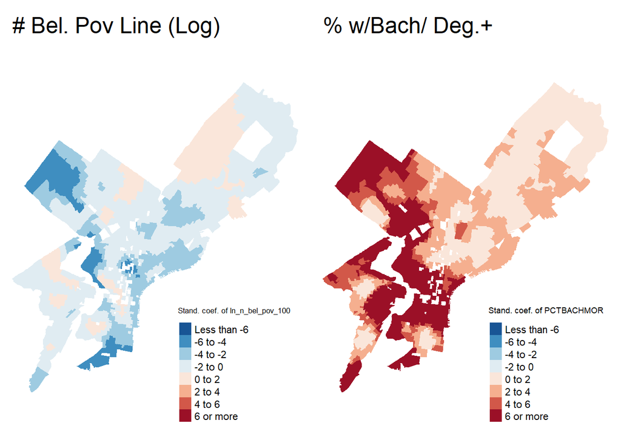

```r
tmap_arrange(coef_pctsingles_adapt_stand_map,
             coef_pctvacant_adapt_stand_map,
             ncol=2)
```

```
## Variable(s) "coef_pctsingles_adapt_stand" contains positive and negative values, so midpoint is set to 0. Set midpoint = NA to show the full spectrum of the color palette.
```

```
## Variable(s) "coef_pctvacant_adapt_stand" contains positive and negative values, so midpoint is set to 0. Set midpoint = NA to show the full spectrum of the color palette.
```

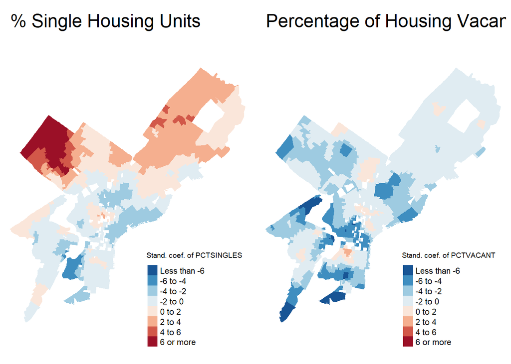

### 3.4.3 Local GWR R-Squared Results

[figure not shown]

```r
tm_shape(reg_data)+
  tm_fill(col = 'gwr_adapt_r2',
          breaks = c(0, 0.1, 0.2, 0.3, 0.4, 0.5, 0.6, 0.7, 0.8),
          n = 5,
          palette = 'Blues',
          title = "R Squared")+
  tm_layout(frame = FALSE,
  main.title = 'Local R Squared')
```

### 3.4.4 Local GWR Residuals Results

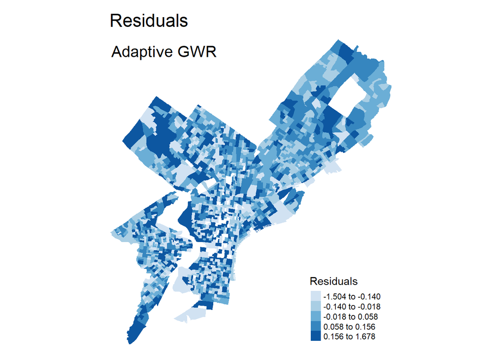

```r
tm_shape(reg_data)+
  tm_fill(col = 'gwr_adapt_resids',
          style = 'quantile',
          palette = 'Blues',
          title = "Residuals",
          midpoint = 0)+
  tm_layout(frame = FALSE,
  main.title = 'Residuals',
  title = "Adaptive GWR")
```

### 3.4.5 Moran’s I Scatterplot of GWR Residuals

2. Present the Moran’s I scatterplot of GWR residuals. Does there seem to be less spatial autocorrelation in these residuals than in OLS residuals? What about the Spatial Lag and Spatial Error Residuals.

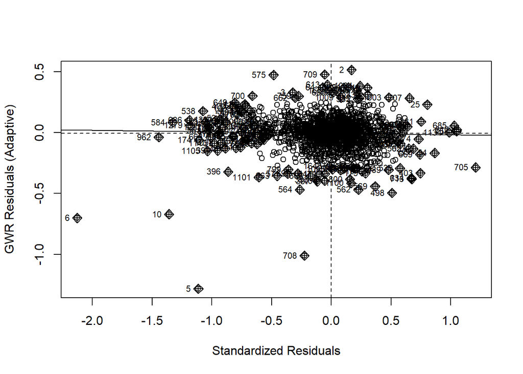

```r
moran.plot(reg_data$gwr_adapt_resids, nb2listw(reg_data$nb),
           xlab = "Standardized Residuals",
            ylab = "GWR Residuals (Adaptive)")
```

## 3.5 Model Comparison

We can do the following to compare all 4 models: 1. Look at the Moran’s I of the residuals from each model and choose the model with the lowest (absolute) Moran’s I 2. Compare the AIC values from each model and choose the model with the lowest value In addition, we can do the following to compare the Spatial Lag Model to OLS: 1. Compare the log likelihoods; the model with the higher value is the better one. 2. Examine the results of the likelihood ratio test; if it’s significant, the Spatial Lag Model is better than OLS. In addition, we can do the following to compare the Spatial Error Model to OLS: 1. Compare the log likelihoods; the model with the higher value is the better one. 2. Examine the results of the likelihood ratio test; if it’s significant, the Spatial Error Model is better than OLS.

Note that the global R^2 for our GWR here is not exactly the same as in the actual function output; we’re calculating it [based on the source code](https://stackoverflow.com/questions/43927662/return-the-global-r2-of-a-geographically-weighted-regression-gwr-in-r) so that it will be automatically update in the table.

```r
model = c("OLS", "Spatial Lag", "Spatial Error", "GWR")
global_moran = c(global_moran_perm(reg$residuals, reg_data$nb, reg_data$weights, alternative = "two.sided", 999)$statistic,
                 global_moran_perm(spatial_lag_reg$residuals, reg_data$nb, reg_data$weights, alternative = "two.sided", 999)$statistic,
                 global_moran_perm(spatial_error_reg$residuals, reg_data$nb, reg_data$weights, alternative = "two.sided", 999)$statistic,
                 global_moran_perm(reg_data$gwr_adapt_resids, reg_data$nb, reg_data$weights, alternative = "two.sided", 999)$statistic)

aic = c(stepAIC(reg)$anova$AIC,
        spatial_lag_reg$AIC_lm.model, #there's a difference between AIC and AIC for the lm for both this and spatial error
        spatial_error_reg$AIC_lm.model, #not sure why that is--might have to ask Eugene
        #also, why are these both the same?? they shouldn't be...
        gwrmodel_adaptive$results$AICh)
```

```
## Start:  AIC=-3439.85
## LNMEDINC ~ LNMEDHVAL + PCTVACANT
##
##             Df Sum of Sq    RSS     AIC
## <none>                   231.99 -3439.9
## - PCTVACANT  1     9.901 241.89 -3370.0
## - LNMEDHVAL  1    93.429 325.41 -2859.8
```

```r
log_lik = c(logLik(reg), logLik(spatial_lag_reg), NA, NA)

lik_ratio = c(NA, LR.Sarlm(spatial_lag_reg, reg)$statistic, LR.Sarlm(spatial_error_reg, reg)$statistic, NA)

lik_rat_p = c(NA, LR.Sarlm(spatial_lag_reg, reg)$p.value, LR.Sarlm(spatial_error_reg, reg)$p.value, NA)

r2 = c(summary(reg)$r.squared, NA, NA, (1 - (gwrmodel_adaptive$results$rss/gwrmodel_adaptive$gTSS))) #am I meant to be using r squared or ADJUSTED r squared?
                                            # calculating global r squared for gwr based on: https://stackoverflow.com/questions/43927662/return-the-global-r2-of-a-geographically-weighted-regression-gwr-in-r

comp = cbind(model,
             round(global_moran, 3),
             round(aic, 1),
             round(log_lik, 4),
             round(lik_ratio, 1),
             lik_rat_p,
             round(r2, 4)) |>
      as.data.frame()

colnames(comp) = c("Model", "Moran's I", "AIC", "Log Likelihood", "Likelihood Ratio", "L.R. P-Value", "R^2")

table_out = comp |>
        gt() |>
        tab_header(
          title = md("**Model Comparison**"))

#print output
table_out
```

**Model Comparison**

| Model | Moran's I | AIC | Log Likelihood | Likelihood Ratio | L.R. P-Value | R^2 |
| --- | --- | --- | --- | --- | --- | --- |
| OLS | 0.205 | -3439.9 | -717.6489 | NA | NA | 0.441 |
| Spatial Lag | -0.041 | 1443.3 | -598.9141 | 237.5 | 0 | NA |
| Spatial Error | -0.032 | 1443.3 | NA | 173.5 | 0 | NA |
| GWR | -0.013 | 861 | NA | NA | NA | 0.6348 |

Eugene says: “Lastly, we can also do the following to compare GWR to OLS: 1. Compare the R2 from OLS with the Quasi-global R2 from GWR; the model with the higher value is the better one. 2. Examine whether there’s spatial variability in standardized coefficients or local R2 values. If there is, it might mean that a single global regression might not capture the varying spatial relationships between the dependent variable and the predictors.”

However, I don’t think means that for #2 we can look at *local* $R^2$ or coefficients, because I don’t think those exist for an OLS model—only for a spatial model. We should ask about this, though.

I also cannot figure out why that last map isn’t rendering right. It does in mapview!

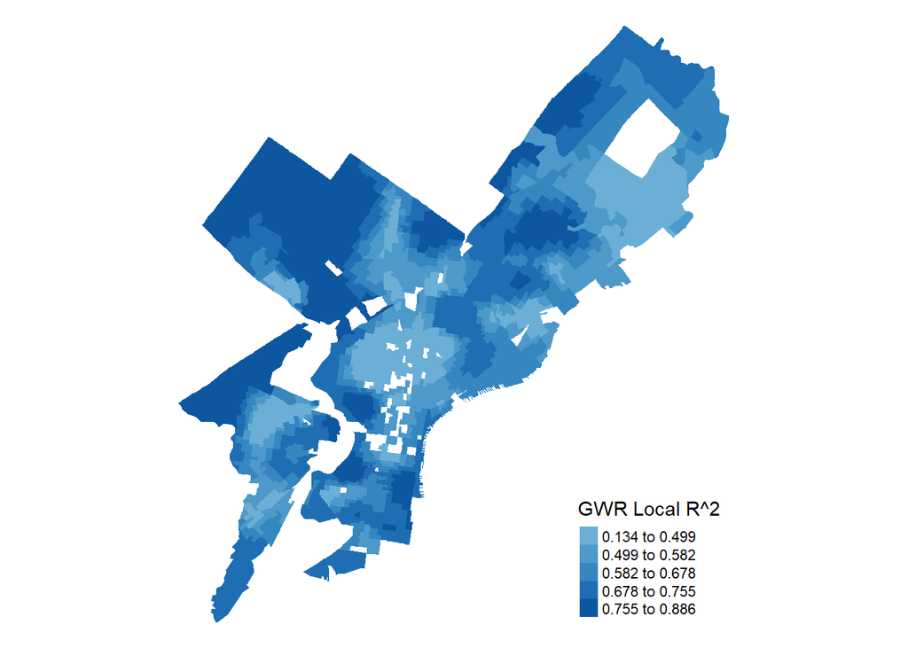

```r
gwr_local_r2 = tm_shape(reg_data)+
                          tm_fill(col = 'gwr_adapt_r2',
                                  style = 'quantile',
                                  title = 'GWR Local R^2',
                                  palette = 'Blues',
                                midpoint = 0)+
                          tm_layout(frame = FALSE)

gwr_coef_ln_n_bel_pov_100 = tm_shape(reg_data)+
                        tm_fill(col = 'coef_ln_n_bel_pov_100_adapt_stand',
                                style = 'quantile',
                                title = 'GWR Coef., ln_n_bel_pov_100',
                                palette = 'Blues',
                                midpoint = 0)+
                        tm_layout(frame = FALSE)

gwr_coef_pctbachmor = tm_shape(reg_data)+
                        tm_fill(col = 'coef_pctbachmor_adapt_stand',
                                style = 'quantile',
                                title = 'GWR Coef., PCTBACHMOR',
                                palette = 'Blues',
                                midpoint = 0)+
                        tm_layout(frame = FALSE)

gwr_coef_pctsingles = tm_shape(reg_data)+
                        tm_fill(col = 'coef_pctsingles_adapt_stand',
                                style = 'quantile',
                                title = 'GWR Coef., PCTSINGLES',
                                palette = 'Blues',
                                midpoint = 0)+
                        tm_layout(frame = FALSE)


gwr_coef_pctvacant = tm_shape(reg_data)+
                        tm_fill(col = 'coef_pctvacant_adapt_stand',
                                style = 'quantile',
                                title = 'GWR Coef., PCTVACANT',
                                palette = 'Blues',
                                midpoint = 0)+
                        tm_layout(frame = FALSE)

# mapview(reg_data, zcol = 'coef_pctvacant_adapt_stand')

gwr_local_r2
```

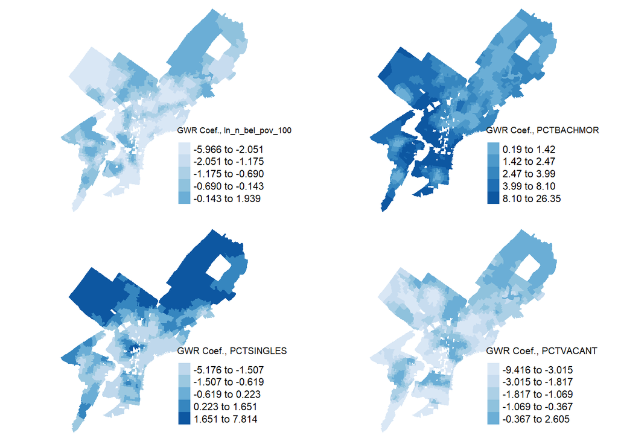

```r
tmap_arrange(gwr_coef_ln_n_bel_pov_100,
             gwr_coef_pctbachmor,
             gwr_coef_pctsingles,
             gwr_coef_pctvacant,
             ncol = 2)
```

# 4 Discussion

In this project, we used three approaches in creating model other than OLS, including spatial lag, spatial error, and geographically weighted regression (GWR), to check whether they can better account for spatial autocorrelation than OLS.

# 5 Citations

```r
url = "https://www.smbc-comics.com/comics/1618931828-20210420.png"
```

[figure not shown]

[^1]: Stephen Malpezzi, Larry Ozanne, and Thomas Thibodaeu, Characteristic Prices of Housing in Fifty-nine Metropolitan Areas (Washington D.C.: Department of Housing and Urban Development: 1980).
[^2]: Stephen Malpezzi, Gregory H. Chun, and Richard K. Green, “New Place-to-Place Housing Price Indexes for U.S. Metropolitan Areas, and Their Determinants,” Real Estate Economics 26, No. 2 (1998): 235-274. https://doi-org.proxy.library.upenn.edu/10.1111/1540-6229.00745
[^3]: Malpezzi, Chun, and Green, “Place-to-Place Housing Price Index,” 238.
[^4]: This analysis is based on [Data Analysis and Visualization with R:Spatial (2022)](http://www.geo.hunter.cuny.edu/~ssun/R-Spatial/)